# TCGA tutorial

## Setting up the data

Import the counts file.

```r
tcga_rna <- read_tsv("data/brca_tcga/data_RNA_Seq_v2_expression_median.txt")

tcga_rna
```

```
## # A tibble: 20,531 x 1,102
##    Hugo_Symbol Entrez_Gene_Id `TCGA-3C-AAAU-0… `TCGA-3C-AALI-0… `TCGA-3C-AALJ-0…
##    <chr>                <dbl>            <dbl>            <dbl>            <dbl>
##  1 LOC1001304…      100130426              0              0                0.907
##  2 UBE2Q2P3         100133144             16.4            9.27            11.6
##  3 UBE2Q2P3         100134869             12.9           17.4              9.23
##  4 HMGB1P1              10357             52.2           69.8            154.
##  5 TIMM23               10431            408.           564.            1361.
##  6 MOXD2               136542              0              0                0
##  7 LOC155060           155060           1187.           516.             592.
##  8 RNU12-2P             26823              0              1.09             0
##  9 SSX9                280660              0              0.544            0
## 10 LOC317712           317712              0              0                0
## # … with 20,521 more rows, and 1,097 more variables: TCGA-3C-AALK-01 <dbl>,
## #   TCGA-4H-AAAK-01 <dbl>, TCGA-5L-AAT0-01 <dbl>, TCGA-5L-AAT1-01 <dbl>,
## #   TCGA-5T-A9QA-01 <dbl>, TCGA-A1-A0SB-01 <dbl>, TCGA-A1-A0SD-01 <dbl>,
## #   TCGA-A1-A0SE-01 <dbl>, TCGA-A1-A0SF-01 <dbl>, TCGA-A1-A0SG-01 <dbl>,
## #   TCGA-A1-A0SH-01 <dbl>, TCGA-A1-A0SI-01 <dbl>, TCGA-A1-A0SJ-01 <dbl>,
## #   TCGA-A1-A0SK-01 <dbl>, TCGA-A1-A0SM-01 <dbl>, TCGA-A1-A0SN-01 <dbl>,
## #   TCGA-A1-A0SO-01 <dbl>, TCGA-A1-A0SP-01 <dbl>, TCGA-A1-A0SQ-01 <dbl>,
## #   TCGA-A2-A04N-01 <dbl>, TCGA-A2-A04P-01 <dbl>, TCGA-A2-A04Q-01 <dbl>,
## #   TCGA-A2-A04R-01 <dbl>, TCGA-A2-A04T-01 <dbl>, TCGA-A2-A04U-01 <dbl>,
## #   TCGA-A2-A04V-01 <dbl>, TCGA-A2-A04W-01 <dbl>, TCGA-A2-A04X-01 <dbl>,
## #   TCGA-A2-A04Y-01 <dbl>, TCGA-A2-A0CK-01 <dbl>, TCGA-A2-A0CL-01 <dbl>,
## #   TCGA-A2-A0CM-01 <dbl>, TCGA-A2-A0CO-01 <dbl>, TCGA-A2-A0CP-01 <dbl>,
## #   TCGA-A2-A0CQ-01 <dbl>, TCGA-A2-A0CR-01 <dbl>, TCGA-A2-A0CS-01 <dbl>,
## #   TCGA-A2-A0CT-01 <dbl>, TCGA-A2-A0CU-01 <dbl>, TCGA-A2-A0CV-01 <dbl>,
## #   TCGA-A2-A0CW-01 <dbl>, TCGA-A2-A0CX-01 <dbl>, TCGA-A2-A0CY-01 <dbl>,
## #   TCGA-A2-A0CZ-01 <dbl>, TCGA-A2-A0D0-01 <dbl>, TCGA-A2-A0D1-01 <dbl>,
## #   TCGA-A2-A0D2-01 <dbl>, TCGA-A2-A0D3-01 <dbl>, TCGA-A2-A0D4-01 <dbl>,
## #   TCGA-A2-A0EM-01 <dbl>, TCGA-A2-A0EN-01 <dbl>, TCGA-A2-A0EO-01 <dbl>,
## #   TCGA-A2-A0EP-01 <dbl>, TCGA-A2-A0EQ-01 <dbl>, TCGA-A2-A0ER-01 <dbl>,
## #   TCGA-A2-A0ES-01 <dbl>, TCGA-A2-A0ET-01 <dbl>, TCGA-A2-A0EU-01 <dbl>,
## #   TCGA-A2-A0EV-01 <dbl>, TCGA-A2-A0EW-01 <dbl>, TCGA-A2-A0EX-01 <dbl>,
## #   TCGA-A2-A0EY-01 <dbl>, TCGA-A2-A0ST-01 <dbl>, TCGA-A2-A0SU-01 <dbl>,
## #   TCGA-A2-A0SV-01 <dbl>, TCGA-A2-A0SW-01 <dbl>, TCGA-A2-A0SX-01 <dbl>,
## #   TCGA-A2-A0SY-01 <dbl>, TCGA-A2-A0T0-01 <dbl>, TCGA-A2-A0T1-01 <dbl>,
## #   TCGA-A2-A0T2-01 <dbl>, TCGA-A2-A0T3-01 <dbl>, TCGA-A2-A0T4-01 <dbl>,
## #   TCGA-A2-A0T5-01 <dbl>, TCGA-A2-A0T6-01 <dbl>, TCGA-A2-A0T7-01 <dbl>,
## #   TCGA-A2-A0YC-01 <dbl>, TCGA-A2-A0YD-01 <dbl>, TCGA-A2-A0YE-01 <dbl>,
## #   TCGA-A2-A0YF-01 <dbl>, TCGA-A2-A0YG-01 <dbl>, TCGA-A2-A0YH-01 <dbl>,
## #   TCGA-A2-A0YI-01 <dbl>, TCGA-A2-A0YJ-01 <dbl>, TCGA-A2-A0YK-01 <dbl>,
## #   TCGA-A2-A0YL-01 <dbl>, TCGA-A2-A0YM-01 <dbl>, TCGA-A2-A0YT-01 <dbl>,
## #   TCGA-A2-A1FV-01 <dbl>, TCGA-A2-A1FW-01 <dbl>, TCGA-A2-A1FX-01 <dbl>,
## #   TCGA-A2-A1FZ-01 <dbl>, TCGA-A2-A1G0-01 <dbl>, TCGA-A2-A1G1-01 <dbl>,
## #   TCGA-A2-A1G4-01 <dbl>, TCGA-A2-A1G6-01 <dbl>, TCGA-A2-A259-01 <dbl>,
## #   TCGA-A2-A25A-01 <dbl>, TCGA-A2-A25B-01 <dbl>, TCGA-A2-A25C-01 <dbl>, …
```

Convert to long format.

```r
tcga_long <- tcga_rna %>%
    pivot_longer(cols=-c(Hugo_Symbol, Entrez_Gene_Id))

tcga_long
```

```
## # A tibble: 22,584,100 x 4
##    Hugo_Symbol  Entrez_Gene_Id name            value
##    <chr>                 <dbl> <chr>           <dbl>
##  1 LOC100130426      100130426 TCGA-3C-AAAU-01 0
##  2 LOC100130426      100130426 TCGA-3C-AALI-01 0
##  3 LOC100130426      100130426 TCGA-3C-AALJ-01 0.907
##  4 LOC100130426      100130426 TCGA-3C-AALK-01 0
##  5 LOC100130426      100130426 TCGA-4H-AAAK-01 0
##  6 LOC100130426      100130426 TCGA-5L-AAT0-01 0
##  7 LOC100130426      100130426 TCGA-5L-AAT1-01 0
##  8 LOC100130426      100130426 TCGA-5T-A9QA-01 0
##  9 LOC100130426      100130426 TCGA-A1-A0SB-01 0
## 10 LOC100130426      100130426 TCGA-A1-A0SD-01 0
## # … with 22,584,090 more rows
```

Import the clinical patient information file. Use `comment=` to skip lines starting with #, header lines. Use `guess_max=` some big number greater than the expected number of rows so column types are correctly guessed.

```r
tcga_clinical <- read_tsv("data/brca_tcga/data_bcr_clinical_data_patient.txt", comment = "#", guess_max=100000)

tcga_clinical
```

```
## # A tibble: 1,097 x 111
##    OTHER_PATIENT_ID           PATIENT_ID  FORM_COMPLETION_D… PROSPECTIVE_COLLEC…
##    <chr>                      <chr>       <chr>              <chr>
##  1 6E7D5EC6-A469-467C-B748-2… TCGA-3C-AA… 1/13/14            NO
##  2 55262FCB-1B01-4480-B322-3… TCGA-3C-AA… 7/28/14            NO
##  3 427D0648-3F77-4FFC-B52C-8… TCGA-3C-AA… 7/28/14            NO
##  4 C31900A4-5DCD-4022-97AC-6… TCGA-3C-AA… 7/28/14            NO
##  5 6623FC5E-00BE-4476-967A-C… TCGA-4H-AA… 11/13/14           YES
##  6 86C6F993-327F-4525-9983-2… TCGA-5L-AA… 8/15/14            NO
##  7 16FC3677-0393-4ED1-AD3F-C… TCGA-5L-AA… 8/15/14            NO
##  8 2FD36838-5A83-433E-AC80-B… TCGA-5T-A9… 12/23/13           YES
##  9 0045349c-69d9-4306-a403-c… TCGA-A1-A0… 6/30/11            NO
## 10 c462e422-eb8d-4daf-9897-2… TCGA-A1-A0… 9/7/11             NO
## # … with 1,087 more rows, and 107 more variables:
## #   RETROSPECTIVE_COLLECTION <chr>, SEX <chr>, MENOPAUSE_STATUS <chr>,
## #   RACE <chr>, ETHNICITY <chr>, HISTORY_OTHER_MALIGNANCY <chr>,
## #   HISTORY_NEOADJUVANT_TRTYN <chr>, TUMOR_STATUS <chr>,
## #   RADIATION_TREATMENT_ADJUVANT <chr>, PHARMACEUTICAL_TX_ADJUVANT <chr>,
## #   HISTOLOGICAL_SUBTYPE <chr>, INITIAL_PATHOLOGIC_DX_YEAR <chr>, AGE <chr>,
## #   METHOD_OF_INITIAL_SAMPLE_PROCUREMENT <chr>,
## #   METHOD_OF_INITIAL_SAMPLE_PROCUREMENT_OTHER <chr>,
## #   SURGICAL_PROCEDURE_FIRST <chr>, FIRST_SURGICAL_PROCEDURE_OTHER <chr>,
## #   PATH_MARGIN <chr>, SURGERY_FOR_POSITIVE_MARGINS <chr>,
## #   SURGERY_FOR_POSITIVE_MARGINS_OTHER <chr>, MARGIN_STATUS_REEXCISION <chr>,
## #   STAGING_SYSTEM <chr>, STAGING_SYSTEM_OTHER <chr>,
## #   MICROMET_DETECTION_BY_IHC <chr>, LYMPH_NODES_EXAMINED <chr>,
## #   LYMPH_NODE_EXAMINED_COUNT <chr>, LYMPH_NODES_EXAMINED_HE_COUNT <chr>,
## #   LYMPH_NODES_EXAMINED_IHC_COUNT <chr>, AJCC_STAGING_EDITION <chr>,
## #   AJCC_TUMOR_PATHOLOGIC_PT <chr>, AJCC_NODES_PATHOLOGIC_PN <chr>,
## #   AJCC_METASTASIS_PATHOLOGIC_PM <chr>, AJCC_PATHOLOGIC_TUMOR_STAGE <chr>,
## #   METASTATIC_SITE_PATIENT <chr>, METASTATIC_SITE_OTHER <chr>,
## #   ER_STATUS_BY_IHC <chr>, ER_STATUS_IHC_PERCENT_POSITIVE <chr>,
## #   ER_POSITIVITY_SCALE_USED <chr>, IHC_SCORE <chr>,
## #   ER_POSITIVITY_SCALE_OTHER <chr>, BRACHYTHERAPY_TOTAL_DOSE_POINT_A <chr>,
## #   PR_STATUS_BY_IHC <chr>, PR_STATUS_IHC_PERCENT_POSITIVE <chr>,
## #   PR_POSITIVITY_SCALE_USED <chr>, PR_POSITIVITY_IHC_INTENSITY_SCORE <chr>,
## #   PR_POSITIVITY_SCALE_OTHER <chr>, PR_POSITIVITY_DEFINE_METHOD <chr>,
## #   IHC_HER2 <chr>, HER2_IHC_PERCENT_POSITIVE <chr>, HER2_IHC_SCORE <chr>,
## #   HER2_POSITIVITY_SCALE_OTHER <chr>, HER2_POSITIVITY_METHOD_TEXT <chr>,
## #   HER2_FISH_STATUS <chr>, HER2_COPY_NUMBER <chr>, CENT17_COPY_NUMBER <chr>,
## #   HER2_AND_CENT17_CELLS_COUNT <chr>, HER2_CENT17_RATIO <chr>,
## #   HER2_AND_CENT17_SCALE_OTHER <chr>, HER2_FISH_METHOD <chr>,
## #   NEW_TUMOR_EVENT_AFTER_INITIAL_TREATMENT <chr>, NTE_ER_STATUS <chr>,
## #   NTE_ER_STATUS_IHC_POSITIVE <chr>, NTE_ER_IHC_INTENSITY_SCORE <chr>,
## #   NTE_ER_POSITIVITY_OTHER_SCALE <chr>, NTE_ER_POSITIVITY_DEFINE_METHOD <chr>,
## #   NTE_PR_STATUS_BY_IHC <chr>, NTE_PR_STATUS_IHC_POSITIVE <chr>,
## #   NTE_PR_IHC_INTENSITY_SCORE <chr>, NTE_PR_POSITIVITY_OTHER_SCALE <chr>,
## #   NTE_PR_POSITIVITY_DEFINE_METHOD <chr>, NTE_HER2_STATUS <chr>,
## #   NTE_HER2_STATUS_IHC_POSITIVE <chr>, NTE_HER2_POSITIVITY_IHC_SCORE <chr>,
## #   NTE_HER2_POSITIVITY_OTHER_SCALE <chr>, NTE_HER2_POSITIVITY_METHOD <chr>,
## #   NTE_HER2_FISH_STATUS <chr>, NTE_HER2_SIGNAL_NUMBER <chr>,
## #   NTE_CENT_17_SIGNAL_NUMBER <chr>, HER2_CENT17_COUNTED_CELLS_COUNT <chr>,
## #   NTE_CENT_17_HER2_RATIO <chr>, NTE_CENT17_HER2_OTHER_SCALE <chr>,
## #   NTE_HER2_FISH_DEFINE_METHOD <chr>, PRIMARY_SITE_PATIENT <chr>,
## #   CLIN_M_STAGE <chr>, CLIN_N_STAGE <chr>, CLIN_T_STAGE <chr>,
## #   CLINICAL_STAGE <chr>, DAYS_TO_INITIAL_PATHOLOGIC_DIAGNOSIS <chr>,
## #   DAYS_TO_PATIENT_PROGRESSION_FREE <chr>, DAYS_TO_TUMOR_PROGRESSION <chr>,
## #   DISEASE_CODE <chr>, EXTRANODAL_INVOLVEMENT <chr>,
## #   HISTOLOGICAL_DIAGNOSIS <chr>, ICD_10 <chr>, ICD_O_3_HISTOLOGY <chr>,
## #   ICD_O_3_SITE <chr>, INFORMED_CONSENT_VERIFIED <chr>,
## #   METASTATIC_TUMOR_INDICATOR <chr>, PROJECT_CODE <chr>,
## #   PRIMARY_SITE_OTHER <chr>, …
```

There are a few columns for HER2.

```r
tcga_clinical %>% select(contains("HER2")) %>% colnames()
```

```
##  [1] "IHC_HER2"                        "HER2_IHC_PERCENT_POSITIVE"
##  [3] "HER2_IHC_SCORE"                  "HER2_POSITIVITY_SCALE_OTHER"
##  [5] "HER2_POSITIVITY_METHOD_TEXT"     "HER2_FISH_STATUS"
##  [7] "HER2_COPY_NUMBER"                "HER2_AND_CENT17_CELLS_COUNT"
##  [9] "HER2_CENT17_RATIO"               "HER2_AND_CENT17_SCALE_OTHER"
## [11] "HER2_FISH_METHOD"                "NTE_HER2_STATUS"
## [13] "NTE_HER2_STATUS_IHC_POSITIVE"    "NTE_HER2_POSITIVITY_IHC_SCORE"
## [15] "NTE_HER2_POSITIVITY_OTHER_SCALE" "NTE_HER2_POSITIVITY_METHOD"
## [17] "NTE_HER2_FISH_STATUS"            "NTE_HER2_SIGNAL_NUMBER"
## [19] "HER2_CENT17_COUNTED_CELLS_COUNT" "NTE_CENT_17_HER2_RATIO"
## [21] "NTE_CENT17_HER2_OTHER_SCALE"     "NTE_HER2_FISH_DEFINE_METHOD"
```

We’ll use the HER2_IHC_Score and HER2_FISH_STATUS columns. We’ll check how mnay samples we’ve got for each category in these columns.

```r
tcga_clinical %>% count(HER2_IHC_SCORE, HER2_FISH_STATUS)
```

```
## # A tibble: 18 x 3
##    HER2_IHC_SCORE  HER2_FISH_STATUS     n
##    <chr>           <chr>            <int>
##  1 [Not Available] [Not Available]    356
##  2 [Not Available] [Not Evaluated]      1
##  3 [Not Available] Equivocal            2
##  4 [Not Available] Indeterminate        4
##  5 [Not Available] Negative            96
##  6 [Not Available] Positive            16
##  7 0               [Not Available]     43
##  8 0               Negative            18
##  9 1               [Not Available]    193
## 10 1               Negative            76
## 11 1               Positive             3
## 12 2               [Not Available]     22
## 13 2               Equivocal            3
## 14 2               Negative           138
## 15 2               Positive            36
## 16 3               [Not Available]     62
## 17 3               Negative             5
## 18 3               Positive            23
```

We will create a column for the her2 groups of interest. We’ll call samples Her2_pos if HER2_IHC_SCORE = 3 and/or HER2_FISH_STATUS = Positive Her2_low if HER2_IHC_SCORE = 1 or 2 and HER2_FISH_STATUS = Negative Her2_neg if HER2_IHC_SCORE = 0

We’ll also filter to only keep samples that are in our groups of interest.

```r
groups <- c("HER2_pos", "HER2_low", "HER2_neg")

tcga_her2 <- tcga_clinical %>%
    mutate(her2_group = case_when((HER2_IHC_SCORE == 3 | HER2_FISH_STATUS == "Positive") ~ "HER2_pos",
                             ((HER2_IHC_SCORE == 1 | HER2_IHC_SCORE == 2) & HER2_FISH_STATUS == "Negative") ~ "HER2_low",
                             HER2_IHC_SCORE == 0 ~ "HER2_neg"
                             )) %>%
    filter(her2_group %in% groups)

tcga_her2
```

```
## # A tibble: 420 x 112
##    OTHER_PATIENT_ID           PATIENT_ID  FORM_COMPLETION_D… PROSPECTIVE_COLLEC…
##    <chr>                      <chr>       <chr>              <chr>
##  1 2FD36838-5A83-433E-AC80-B… TCGA-5T-A9… 12/23/13           YES
##  2 c397e6c2-ba3a-4f5e-a258-c… TCGA-A1-A0… 12/6/10            NO
##  3 a6a863d9-b39d-4965-b47f-7… TCGA-A1-A0… 12/6/10            NO
##  4 a2db9dd1-44d5-48b5-817c-a… TCGA-A1-A0… 12/6/10            NO
##  5 a5b44d66-c162-46b5-9df2-8… TCGA-A1-A0… 12/6/10            NO
##  6 784de7ac-8424-42eb-83d4-a… TCGA-A1-A0… 12/6/10            NO
##  7 a9bb8159-32f0-454c-a946-b… TCGA-A1-A0… 12/6/10            NO
##  8 b5fba77b-1f50-4e71-95b2-5… TCGA-A2-A0… 8/10/10            NO
##  9 f3a058b9-fb7f-4098-8f0e-8… TCGA-A2-A0… 10/8/10            NO
## 10 b58ad350-5140-4fa8-bc2c-2… TCGA-A2-A0… 8/9/10             NO
## # … with 410 more rows, and 108 more variables: RETROSPECTIVE_COLLECTION <chr>,
## #   SEX <chr>, MENOPAUSE_STATUS <chr>, RACE <chr>, ETHNICITY <chr>,
## #   HISTORY_OTHER_MALIGNANCY <chr>, HISTORY_NEOADJUVANT_TRTYN <chr>,
## #   TUMOR_STATUS <chr>, RADIATION_TREATMENT_ADJUVANT <chr>,
## #   PHARMACEUTICAL_TX_ADJUVANT <chr>, HISTOLOGICAL_SUBTYPE <chr>,
## #   INITIAL_PATHOLOGIC_DX_YEAR <chr>, AGE <chr>,
## #   METHOD_OF_INITIAL_SAMPLE_PROCUREMENT <chr>,
## #   METHOD_OF_INITIAL_SAMPLE_PROCUREMENT_OTHER <chr>,
## #   SURGICAL_PROCEDURE_FIRST <chr>, FIRST_SURGICAL_PROCEDURE_OTHER <chr>,
## #   PATH_MARGIN <chr>, SURGERY_FOR_POSITIVE_MARGINS <chr>,
## #   SURGERY_FOR_POSITIVE_MARGINS_OTHER <chr>, MARGIN_STATUS_REEXCISION <chr>,
## #   STAGING_SYSTEM <chr>, STAGING_SYSTEM_OTHER <chr>,
## #   MICROMET_DETECTION_BY_IHC <chr>, LYMPH_NODES_EXAMINED <chr>,
## #   LYMPH_NODE_EXAMINED_COUNT <chr>, LYMPH_NODES_EXAMINED_HE_COUNT <chr>,
## #   LYMPH_NODES_EXAMINED_IHC_COUNT <chr>, AJCC_STAGING_EDITION <chr>,
## #   AJCC_TUMOR_PATHOLOGIC_PT <chr>, AJCC_NODES_PATHOLOGIC_PN <chr>,
## #   AJCC_METASTASIS_PATHOLOGIC_PM <chr>, AJCC_PATHOLOGIC_TUMOR_STAGE <chr>,
## #   METASTATIC_SITE_PATIENT <chr>, METASTATIC_SITE_OTHER <chr>,
## #   ER_STATUS_BY_IHC <chr>, ER_STATUS_IHC_PERCENT_POSITIVE <chr>,
## #   ER_POSITIVITY_SCALE_USED <chr>, IHC_SCORE <chr>,
## #   ER_POSITIVITY_SCALE_OTHER <chr>, BRACHYTHERAPY_TOTAL_DOSE_POINT_A <chr>,
## #   PR_STATUS_BY_IHC <chr>, PR_STATUS_IHC_PERCENT_POSITIVE <chr>,
## #   PR_POSITIVITY_SCALE_USED <chr>, PR_POSITIVITY_IHC_INTENSITY_SCORE <chr>,
## #   PR_POSITIVITY_SCALE_OTHER <chr>, PR_POSITIVITY_DEFINE_METHOD <chr>,
## #   IHC_HER2 <chr>, HER2_IHC_PERCENT_POSITIVE <chr>, HER2_IHC_SCORE <chr>,
## #   HER2_POSITIVITY_SCALE_OTHER <chr>, HER2_POSITIVITY_METHOD_TEXT <chr>,
## #   HER2_FISH_STATUS <chr>, HER2_COPY_NUMBER <chr>, CENT17_COPY_NUMBER <chr>,
## #   HER2_AND_CENT17_CELLS_COUNT <chr>, HER2_CENT17_RATIO <chr>,
## #   HER2_AND_CENT17_SCALE_OTHER <chr>, HER2_FISH_METHOD <chr>,
## #   NEW_TUMOR_EVENT_AFTER_INITIAL_TREATMENT <chr>, NTE_ER_STATUS <chr>,
## #   NTE_ER_STATUS_IHC_POSITIVE <chr>, NTE_ER_IHC_INTENSITY_SCORE <chr>,
## #   NTE_ER_POSITIVITY_OTHER_SCALE <chr>, NTE_ER_POSITIVITY_DEFINE_METHOD <chr>,
## #   NTE_PR_STATUS_BY_IHC <chr>, NTE_PR_STATUS_IHC_POSITIVE <chr>,
## #   NTE_PR_IHC_INTENSITY_SCORE <chr>, NTE_PR_POSITIVITY_OTHER_SCALE <chr>,
## #   NTE_PR_POSITIVITY_DEFINE_METHOD <chr>, NTE_HER2_STATUS <chr>,
## #   NTE_HER2_STATUS_IHC_POSITIVE <chr>, NTE_HER2_POSITIVITY_IHC_SCORE <chr>,
## #   NTE_HER2_POSITIVITY_OTHER_SCALE <chr>, NTE_HER2_POSITIVITY_METHOD <chr>,
## #   NTE_HER2_FISH_STATUS <chr>, NTE_HER2_SIGNAL_NUMBER <chr>,
## #   NTE_CENT_17_SIGNAL_NUMBER <chr>, HER2_CENT17_COUNTED_CELLS_COUNT <chr>,
## #   NTE_CENT_17_HER2_RATIO <chr>, NTE_CENT17_HER2_OTHER_SCALE <chr>,
## #   NTE_HER2_FISH_DEFINE_METHOD <chr>, PRIMARY_SITE_PATIENT <chr>,
## #   CLIN_M_STAGE <chr>, CLIN_N_STAGE <chr>, CLIN_T_STAGE <chr>,
## #   CLINICAL_STAGE <chr>, DAYS_TO_INITIAL_PATHOLOGIC_DIAGNOSIS <chr>,
## #   DAYS_TO_PATIENT_PROGRESSION_FREE <chr>, DAYS_TO_TUMOR_PROGRESSION <chr>,
## #   DISEASE_CODE <chr>, EXTRANODAL_INVOLVEMENT <chr>,
## #   HISTOLOGICAL_DIAGNOSIS <chr>, ICD_10 <chr>, ICD_O_3_HISTOLOGY <chr>,
## #   ICD_O_3_SITE <chr>, INFORMED_CONSENT_VERIFIED <chr>,
## #   METASTATIC_TUMOR_INDICATOR <chr>, PROJECT_CODE <chr>,
## #   PRIMARY_SITE_OTHER <chr>, …
```

To add the her2 group information to the counts table, we need a column to match on that’s present in both tables. The counts table has SAMPLE_ID but the patient information has PATIENT_ID. We’ll import the sample information table, that has both PATIENT_ID and SAMPLE_ID, and join the patient table to it. Then match to sample id in counts table.

```r
tcga_sample <- read_tsv("data/brca_tcga/data_bcr_clinical_data_sample.txt", comment = "#", guess_max=100000)

tcga_sample
```

```
## # A tibble: 1,108 x 26
##    PATIENT_ID  SAMPLE_ID   OTHER_SAMPLE_ID    SPECIMEN_CURRENT… DAYS_TO_COLLECT…
##    <chr>       <chr>       <chr>              <chr>             <chr>
##  1 TCGA-AR-A1… TCGA-AR-A1… 5fa9998b-deff-493… [Not Available]   1416
##  2 TCGA-BH-A1… TCGA-BH-A1… 9d501ca9-f50d-45f… [Not Available]   4330
##  3 TCGA-BH-A1… TCGA-BH-A1… aa1037f4-1414-4e0… [Not Available]   4242
##  4 TCGA-BH-A1… TCGA-BH-A1… 2190d984-3941-41d… [Not Available]   4137
##  5 TCGA-BH-A1… TCGA-BH-A1… 73af0f78-cc37-43f… [Not Available]   4106
##  6 TCGA-BH-A1… TCGA-BH-A1… 29ac24fb-0065-47f… [Not Available]   4103
##  7 TCGA-BH-A1… TCGA-BH-A1… 50463a25-4292-4bc… [Not Available]   4230
##  8 TCGA-BH-A1… TCGA-BH-A1… f754aa5f-49c8-4e8… [Not Available]   3879
##  9 TCGA-C8-A1… TCGA-C8-A1… f2a49aa7-b756-4ea… [Not Available]   109
## 10 TCGA-C8-A1… TCGA-C8-A1… bed56886-f4fe-491… [Not Available]   122
## # … with 1,098 more rows, and 21 more variables:
## #   DAYS_TO_SPECIMEN_COLLECTION <chr>, SPECIMEN_FREEZING_METHOD <chr>,
## #   SAMPLE_INITIAL_WEIGHT <chr>, SPECIMEN_SECOND_LONGEST_DIMENSION <chr>,
## #   IS_FFPE <chr>, LONGEST_DIMENSION <chr>, METHOD_OF_SAMPLE_PROCUREMENT <chr>,
## #   OCT_EMBEDDED <chr>, OTHER_METHOD_OF_SAMPLE_PROCUREMENT <chr>,
## #   PATHOLOGY_REPORT_FILE_NAME <chr>, PATHOLOGY_REPORT_UUID <chr>,
## #   SAMPLE_TYPE <chr>, SAMPLE_TYPE_ID <dbl>, SHORTEST_DIMENSION <chr>,
## #   TIME_BETWEEN_CLAMPING_AND_FREEZING <chr>,
## #   TIME_BETWEEN_EXCISION_AND_FREEZING <chr>, VIAL_NUMBER <chr>,
## #   ONCOTREE_CODE <chr>, CANCER_TYPE <chr>, CANCER_TYPE_DETAILED <chr>,
## #   SOMATIC_STATUS <chr>
```

Keep just sample id and HER2 column to not have too big table.

```r
# Join her2 table to sample table to get sample id
tcga_joined_sample <- inner_join(tcga_her2, tcga_sample, by = "PATIENT_ID") %>%
    select(SAMPLE_ID, her2_group)

tcga_joined_sample
```

```
## # A tibble: 422 x 2
##    SAMPLE_ID       her2_group
##    <chr>           <chr>
##  1 TCGA-5T-A9QA-01 HER2_low
##  2 TCGA-A1-A0SE-01 HER2_low
##  3 TCGA-A1-A0SH-01 HER2_low
##  4 TCGA-A1-A0SJ-01 HER2_low
##  5 TCGA-A1-A0SK-01 HER2_neg
##  6 TCGA-A1-A0SM-01 HER2_pos
##  7 TCGA-A1-A0SP-01 HER2_neg
##  8 TCGA-A2-A04Q-01 HER2_low
##  9 TCGA-A2-A04R-01 HER2_low
## 10 TCGA-A2-A04T-01 HER2_low
## # … with 412 more rows
```

```r
# Join counts table to her2 status using sample id
tcga_joined <- inner_join(tcga_long, tcga_joined_sample, by = c("name" = "SAMPLE_ID"))

tcga_joined
```

```
## # A tibble: 8,664,082 x 5
##    Hugo_Symbol  Entrez_Gene_Id name            value her2_group
##    <chr>                 <dbl> <chr>           <dbl> <chr>
##  1 LOC100130426      100130426 TCGA-5T-A9QA-01     0 HER2_low
##  2 LOC100130426      100130426 TCGA-A1-A0SE-01     0 HER2_low
##  3 LOC100130426      100130426 TCGA-A1-A0SH-01     0 HER2_low
##  4 LOC100130426      100130426 TCGA-A1-A0SJ-01     0 HER2_low
##  5 LOC100130426      100130426 TCGA-A1-A0SK-01     0 HER2_neg
##  6 LOC100130426      100130426 TCGA-A1-A0SM-01     0 HER2_pos
##  7 LOC100130426      100130426 TCGA-A1-A0SP-01     0 HER2_neg
##  8 LOC100130426      100130426 TCGA-A2-A04Q-01     0 HER2_low
##  9 LOC100130426      100130426 TCGA-A2-A04R-01     0 HER2_low
## 10 LOC100130426      100130426 TCGA-A2-A04T-01     0 HER2_low
## # … with 8,664,072 more rows
```

## Exploratory analysis

### Density plots

Create density plots to visualise the distributions of counts for the samples.

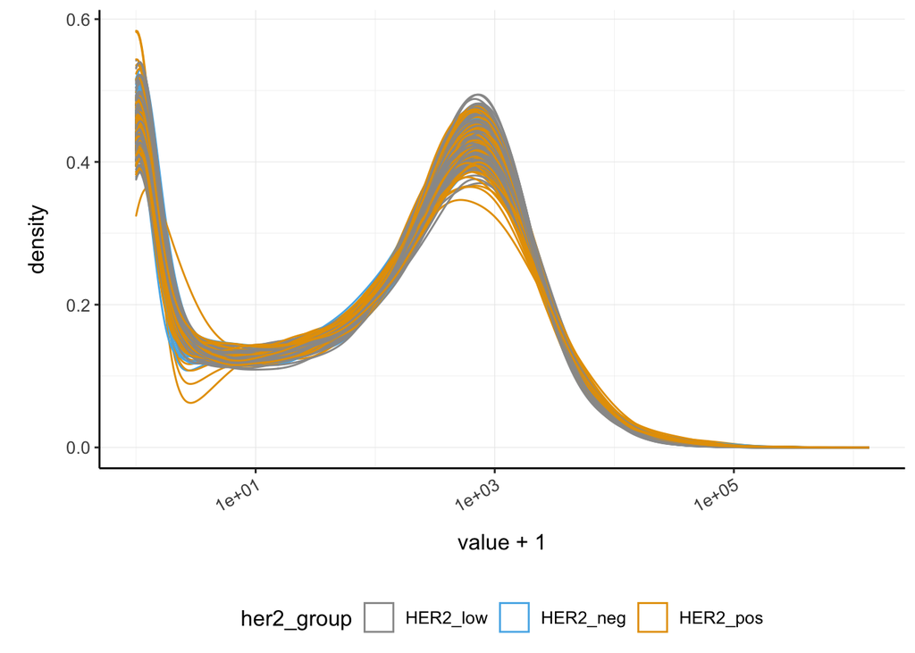

```r
tcga_joined %>%
    ggplot(aes(x = value + 1, group = name, colour= her2_group)) +
    geom_density() +
    scale_x_log10() +
    custom_theme
```

The peak on the left shows there are a lot of genes with zero/low counts. We should filter these genes.

We’ll use the tidybulk package to do the RNA-seq filtering and analysis. First we create a tidybulk tibble (table).

```r
counts_tt <- tcga_joined %>%
    mutate(Entrez_Gene_Id = as.character(Entrez_Gene_Id)) %>%
    tidybulk(.sample = name, .transcript = Entrez_Gene_Id, .abundance = value)

counts_tt
```

```
## # A tibble: 8,664,082 x 5
##    Hugo_Symbol  Entrez_Gene_Id name            value her2_group
##    <chr>        <chr>          <chr>           <dbl> <chr>
##  1 LOC100130426 100130426      TCGA-5T-A9QA-01     0 HER2_low
##  2 LOC100130426 100130426      TCGA-A1-A0SE-01     0 HER2_low
##  3 LOC100130426 100130426      TCGA-A1-A0SH-01     0 HER2_low
##  4 LOC100130426 100130426      TCGA-A1-A0SJ-01     0 HER2_low
##  5 LOC100130426 100130426      TCGA-A1-A0SK-01     0 HER2_neg
##  6 LOC100130426 100130426      TCGA-A1-A0SM-01     0 HER2_pos
##  7 LOC100130426 100130426      TCGA-A1-A0SP-01     0 HER2_neg
##  8 LOC100130426 100130426      TCGA-A2-A04Q-01     0 HER2_low
##  9 LOC100130426 100130426      TCGA-A2-A04R-01     0 HER2_low
## 10 LOC100130426 100130426      TCGA-A2-A04T-01     0 HER2_low
## # … with 8,664,072 more rows
```

There are duplicated genes - same symbol, same gene id - don’t know why e.g. CC2D2B, id 387707. We’ll aggregate these. By default it will sum the counts for these duplicated genes.

```r
# Note to self - caching this step for the moment in the Rmd as it's slow

counts_dupsrem <- counts_tt %>% aggregate_duplicates()
```

After removing duplicate genes, we’ll convert to tidySummarizedExperiment format as that will more efficiently handle this large dataset, will be quicker to process.

```r
counts_se <- counts_dupsrem  %>% as_SummarizedExperiment()
```

### Filtering lowly expressed

Now we’ll filter low counts. We’ll filter using the her2 group information. This uses edgeR filterbyExpr,

```r
counts_filtered <- counts_se %>% keep_abundant(factor_of_interest = her2_group)
```

Check density plots.

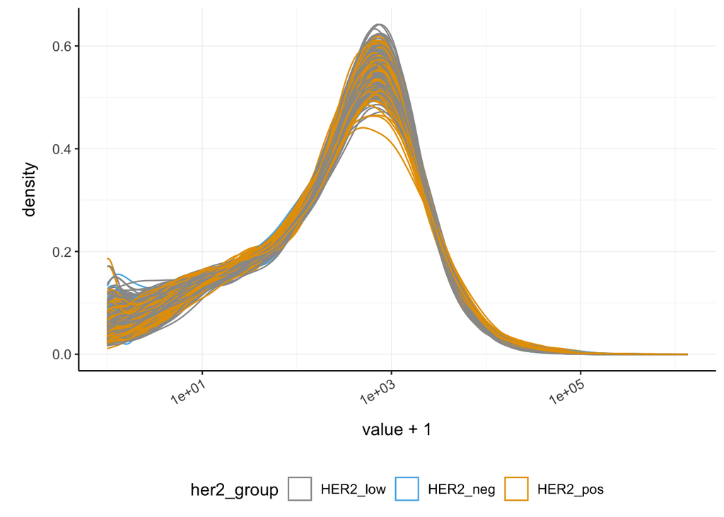

```r
counts_filtered %>%
    ggplot(aes(x = value + 1, group = sample, colour = her2_group)) +
    geom_density() +
    scale_x_log10() +
    custom_theme
```

Now the peak on the left is gone.

### RLE plots

We’ll use RLE plots to check the normalisation. Ref https://journals.plos.org/plosone/article?id=10.1371/journal.pone.0191629

We’ll randomly select 50 samples to be able to see the boxplots.

```r
# Get 50 samples from distinct values of sample id
num <- 50
sample_ids <- counts_filtered %>%
  distinct(sample) %>%
  slice_sample(n=num) %>%
  pull()
```

```
## tidySummarizedExperiment says: A data frame is returned for independent data analysis.
```

```r
# Extract these samples from the full dataset
counts_subsampled <- counts_filtered %>% filter(sample %in% sample_ids)
```

To create the RLE plots we calculate the median log count for each gene and subtract that from the log count for that gene in each sample.

```
## tidySummarizedExperiment says: A data frame is returned for independent data analysis.
```

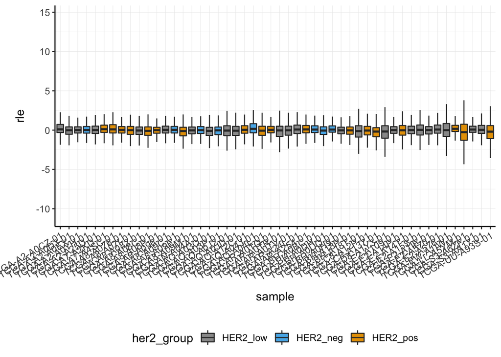

```r
counts_subsampled  %>%
    group_by(feature) %>%
    mutate(gene_median_log = median(log2(value + 1)),
           rle = log2(value + 1) - gene_median_log) %>%
    ggplot(aes(x=sample, y=rle, fill = her2_group)) +
    geom_boxplot(outlier.shape = NA) +
    custom_theme
```

### PCA plots

We’ll create PCA plots to see how the samples group.

```r
#Calculate dimensions
counts_PCA <-
  counts_filtered %>%
  reduce_dimensions(method = "PCA")
```

```
## Getting the 500 most variable genes
```

```
## Fraction of variance explained by the selected principal components
```

```
## # A tibble: 2 x 2
##   `Fraction of variance`    PC
##                    <dbl> <int>
## 1                 0.170      1
## 2                 0.0767     2
```

```
## tidybulk says: to access the raw results do `attr(..., "internals")$PCA`
```

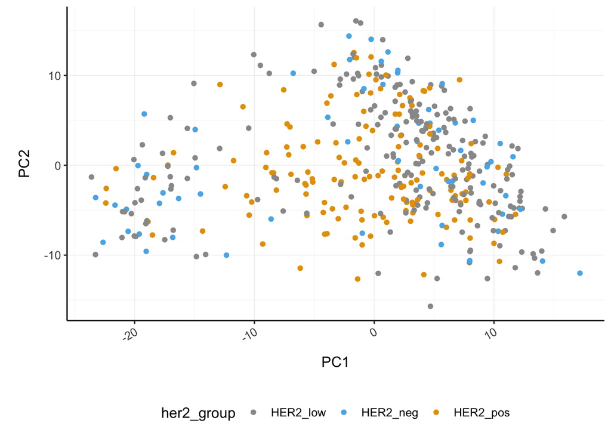

```r
# Plot PCs
counts_PCA %>%
  pivot_sample() %>%
  ggplot(aes(x = PC1, y = PC2, colour = her2_group)) +
  geom_point() +
  custom_theme
```

## Differential expression

We’ll perform differential expression with limma-voom. We’ll compare the HER2_pos to the HER2_neg group.

```r
 counts_de <- counts_PCA %>%
    test_differential_abundance(
    ~ 0 + her2_group,
    .contrasts = c("her2_groupHER2_pos - her2_groupHER2_neg"),
    omit_contrast_in_colnames = TRUE,
    method = "limma_voom"
  )
```

```
## =====================================
## tidybulk says: All testing methods use raw counts, irrespective of if scale_abundance
## or adjust_abundance have been calculated. Therefore, it is essential to add covariates
## such as batch effects (if applicable) in the formula.
## =====================================
```

```
## tidybulk says: The design column names are "her2_groupHER2_low, her2_groupHER2_neg, her2_groupHER2_pos"
```

```
## tidybulk says: to access the raw results (fitted GLM) do `attr(..., "internals")$limma_voom`
```

```r
counts_de
```

```
## # A SummarizedExperiment-tibble abstraction: 6,863,830 x 15
## # Transcripts=16265 | Samples=422 | Assays=value
##    feature sample  value her2_group   PC1   PC2 Hugo_Symbol merged.transcri…
##    <chr>   <chr>   <dbl> <chr>      <dbl> <dbl> <chr>                  <dbl>
##  1 1       TCGA-… 314.   HER2_low    7.95 -10.8 A1BG                       1
##  2 10      TCGA-…   3.66 HER2_low    7.95 -10.8 NAT2                       1
##  3 100     TCGA-… 190.   HER2_low    7.95 -10.8 ADA                        1
##  4 1000    TCGA-…  10.5  HER2_low    7.95 -10.8 CDH2                       1
##  5 10000   TCGA-…  43.4  HER2_low    7.95 -10.8 AKT3                       1
##  6 100009… TCGA-…  78.2  HER2_low    7.95 -10.8 ZBTB11-AS1                 1
##  7 10001   TCGA-… 387.   HER2_low    7.95 -10.8 MED6                       1
##  8 10002   TCGA-…  14.6  HER2_low    7.95 -10.8 NR2E3                      1
##  9 10003   TCGA-…   2.62 HER2_low    7.95 -10.8 NAALAD2                    1
## 10 100033… TCGA-…   0    HER2_low    7.95 -10.8 SNORD116-4                 1
## # … with 40 more rows, and 7 more variables: .abundant <lgl>, logFC <dbl>,
## #   AveExpr <dbl>, t <dbl>, P.Value <dbl>, adj.P.Val <dbl>, B <dbl>
```

### P values histogram

Create histogram of P values. Check if histogram of P values looks appropriate. Ref https://www.ncbi.nlm.nih.gov/pmc/articles/PMC6164648/

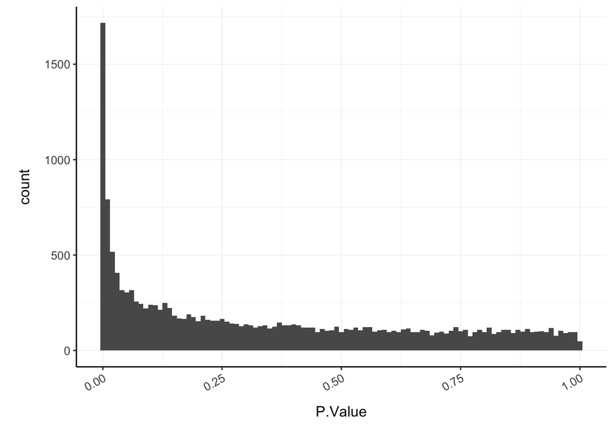

```r
 counts_de %>%
    pivot_transcript() %>%
    ggplot(aes(x = P.Value)) +
    geom_histogram(binwidth= 0.01) +
    custom_theme
```

If you want to save the differential expression results table to a file.

```r
 counts_de %>%
    pivot_transcript() %>%
    write_tsv("tcga_her2_pos_vs_neg.tsv")
```